# Practical Machine Learning Assignment

This project requires us to use data from accelerometers on the belt, forearm, arm, and dumbell of 6 participants and predict the manner in which they did the exercise.

These 6 participants were asked to perform one set of 10 repetitions of the Unilateral Dumbbell Biceps Curl in five different fashions:

- exactly according to the specification : Class A
- throwing the elbows to the front : Class B
- lifting the dumbbell only halfway : Class C
- lowering the dumbbell only halfway : Class D
- throwing the hips to the front : Class E

Class A corresponds to the specified execution of the exercise, while the other 4 classes correspond to common mistakes.

Read more: http://groupware.les.inf.puc-rio.br/har#ixzz3ifoO28iy

## Data

Training data: https://d396qusza40orc.cloudfront.net/predmachlearn/pml-training.csv

Test data: https://d396qusza40orc.cloudfront.net/predmachlearn/pml-testing.csv

Source: http://groupware.les.inf.puc-rio.br/har

## Load data

```r
train = read.csv("pml-training.csv")
test = read.csv("pml-testing.csv")
```

## Load libraries

```r
require(caret)
require(plyr)
require(randomForest)
require(Amelia)
require(rattle)
require(rpart.plot)
require(rpart)
require(gbm)
```

## Create training and validation set

We partition given training set into two parts, with 75% data in the training set and 25% in the vaildation set. We will use the validation set to check the accuracy of the final prediction model.

`createDataPartition` function from `caret` library is used so that there is balanced distribution of observations of each class in the training and validating sets.

```r
set.seed(3523)
inTrain = createDataPartition(train$classe, p = 3/4)[[1]]
cv.train = train[ inTrain,]
cv.validate = train[-inTrain,]
```

## Exploring and cleaning data

Let us look at the training set and try to understand the data.

```r
dim(cv.train)
```

```
## [1] 14718   160
```

```r
head(cv.train[,1:20])
```

```
##   X user_name raw_timestamp_part_1 raw_timestamp_part_2   cvtd_timestamp
## 1 1  carlitos           1323084231               788290 05/12/2011 11:23
## 2 2  carlitos           1323084231               808298 05/12/2011 11:23
## 3 3  carlitos           1323084231               820366 05/12/2011 11:23
## 4 4  carlitos           1323084232               120339 05/12/2011 11:23
## 6 6  carlitos           1323084232               304277 05/12/2011 11:23
## 7 7  carlitos           1323084232               368296 05/12/2011 11:23
##   new_window num_window roll_belt pitch_belt yaw_belt total_accel_belt
## 1         no         11      1.41       8.07    -94.4                3
## 2         no         11      1.41       8.07    -94.4                3
## 3         no         11      1.42       8.07    -94.4                3
## 4         no         12      1.48       8.05    -94.4                3
## 6         no         12      1.45       8.06    -94.4                3
## 7         no         12      1.42       8.09    -94.4                3
##   kurtosis_roll_belt kurtosis_picth_belt kurtosis_yaw_belt
## 1
## 2
## 3
## 4
## 6
## 7
##   skewness_roll_belt skewness_roll_belt.1 skewness_yaw_belt max_roll_belt
## 1                                                                      NA
## 2                                                                      NA
## 3                                                                      NA
## 4                                                                      NA
## 6                                                                      NA
## 7                                                                      NA
##   max_picth_belt max_yaw_belt
## 1             NA
## 2             NA
## 3             NA
## 4             NA
## 6             NA
## 7             NA
```

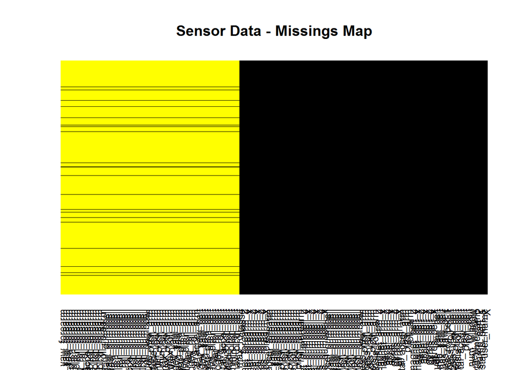

```r
missmap(cv.train, main="Sensor Data - Missings Map",
        col=c("yellow", "black"),
        legend=FALSE,
        y.labels=NULL,
        y.at=NULL)
```

The training set has 14718 observations with 160 variables.

Here, I have removed all those columns which has blanks or NAs more than equal to the number of `new_window == yes` rows. This has been done for validation set as well as for test set.

```r
colsAboveThreshold = apply(train, 2, function(x) count(is.na(x)|x=="")[1,2]>nrow(subset(train, new_window=="yes")))

cv.train = cv.train[,names(cv.train) %in% names(colsAboveThreshold[colsAboveThreshold == T])]
cv.validate = cv.validate[,names(cv.validate) %in% names(colsAboveThreshold[colsAboveThreshold == T])]
test = test[,names(test) %in% names(colsAboveThreshold[colsAboveThreshold == T])]
```

Looking at the dataset, we can also observe that first seven columns are not sensor data and are just book keeping columns, holding details of the user and general information of the experiment. We can safely omit these columns too from our datasets as they have no bearing to the task at hand.

```r
bookkeeping = c("X", "user_name",
                "raw_timestamp_part_1",
                "raw_timestamp_part_2",
                "cvtd_timestamp",
                "new_window",
                "num_window")

cv.train = cv.train[,!names(cv.train) %in% bookkeeping]
cv.validate = cv.validate[,!names(cv.validate) %in% bookkeeping]
test = test[,!names(test) %in% bookkeeping]
```

Our data sets are now ready for buiding model and final predictions.

## Classification Models

### Decision Tree

```r
# set.seed(154)
# CART.tr = train(classe~.,
#               data=cv.train,
#               method="rpart")

# saveRDS(CART.tr, file="CART_tr.rds")
CART.tr = readRDS("CART_tr.rds")

print(CART.tr)
```

```
## CART
##
## 14718 samples
##    52 predictor
##     5 classes: 'A', 'B', 'C', 'D', 'E'
##
## No pre-processing
## Resampling: Bootstrapped (25 reps)
##
## Summary of sample sizes: 14718, 14718, 14718, 14718, 14718, 14718, ...
##
## Resampling results across tuning parameters:
##
##   cp      Accuracy  Kappa   Accuracy SD  Kappa SD
##   0.0343  0.524     0.3879  0.0218       0.0370
##   0.0595  0.401     0.1846  0.0564       0.0951
##   0.1157  0.329     0.0689  0.0421       0.0624
##
## Accuracy was used to select the optimal model using  the largest value.
## The final value used for the model was cp = 0.03427324.
```

The decsion tree model, with parameters `cp = 0.03427324` give the best accuracy of 0.524 on the training set.

```r
CART.fit = rpart(classe~.,
              data=cv.train,
              cp=0.03427324)
```

Let us check accuracy of the model on the validation set.

```r
valPred = predict(CART.fit, newdata=cv.validate[,-53], type="class")
CART.cm = confusionMatrix(valPred, cv.validate$classe)
CART.cm$overall[1]
```

```
##  Accuracy
## 0.4973491
```

Accuracy on validation set is `0.4973491` which is too low.

### Random Forest

Let us use our training set to train a model for tuning and selecting best combination of parameters for training our random forest model. We will use 10-fold cross validation for tuning our parameters.

```r
# set.seed(154)
# fitControl = trainControl(method="cv",
#                           number=10)
# RF.tr = train(classe~.,
#               data=cv.train,
#               method="rf",
#               trControl=fitControl)

# saveRDS(RF.tr, file="RF_tr.rds")
RF.tr = readRDS("RF_tr.rds")

print(RF.tr$finalModel)
```

```
##
## Call:
##  randomForest(x = x, y = y, mtry = param$mtry)
##                Type of random forest: classification
##                      Number of trees: 500
## No. of variables tried at each split: 27
##
##         OOB estimate of  error rate: 0.71%
## Confusion matrix:
##      A    B    C    D    E class.error
## A 4180    3    1    0    1 0.001194743
## B   24 2816    7    1    0 0.011235955
## C    0   18 2539   10    0 0.010907674
## D    0    1   24 2385    2 0.011194030
## E    0    2    4    6 2694 0.004434590
```

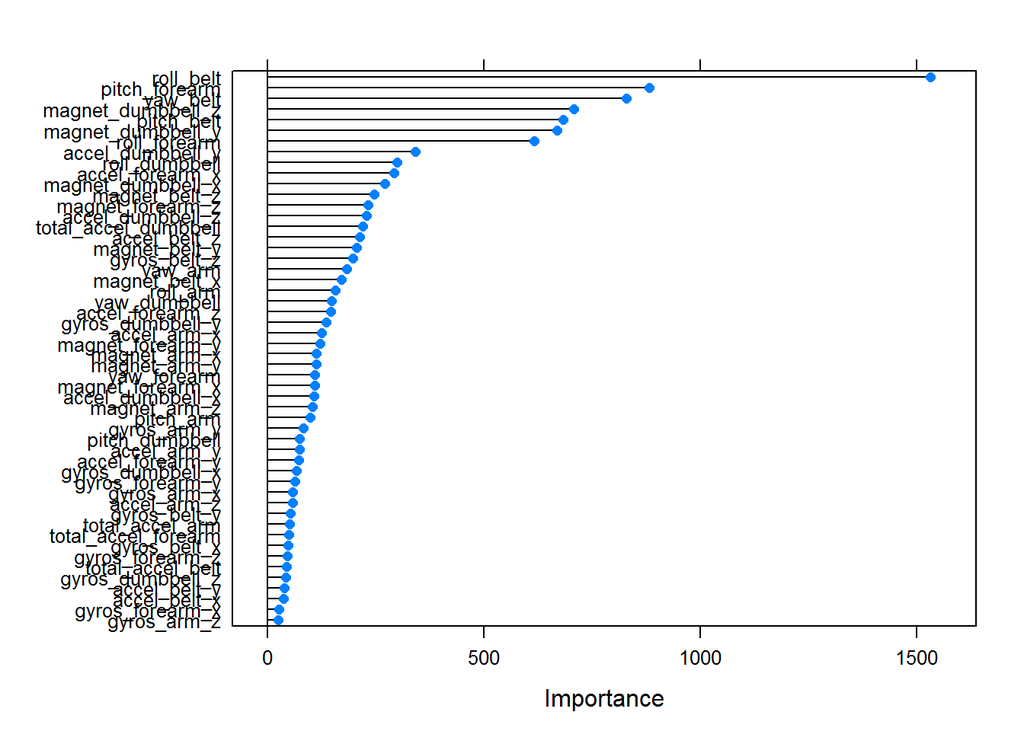

```r
plot(varImp(RF.tr,scale=F))
```

The random forest model, with parameters `mtry = 27` and `ntree = 500`, give us `OOB estimate of error rate: 0.71%`, which is good and we hope to get better error rate when we train the model on full training set using these parameters.

```r
# set.seed(154)
# RF.fit = randomForest(classe~.,
#               data=cv.train,
#               ntree=500,
#               mtry = 27)
#
# saveRDS(RF.fit, file="RF_fit.rds")
RF.fit = readRDS("RF_fit.rds")

print(RF.fit)
```

```
##
## Call:
##  randomForest(formula = classe ~ ., data = cv.train, ntree = 500,      mtry = 27)
##                Type of random forest: classification
##                      Number of trees: 500
## No. of variables tried at each split: 27
##
##         OOB estimate of  error rate: 0.7%
## Confusion matrix:
##      A    B    C    D    E  class.error
## A 4182    2    0    0    1 0.0007168459
## B   24 2817    6    1    0 0.0108848315
## C    0   15 2544    8    0 0.0089598753
## D    0    0   29 2381    2 0.0128524046
## E    0    1    6    8 2691 0.0055432373
```

Our random forest model gives `OOB estimate of error rate: 0.7%` which is very good. Let us validate our model on the validating set to check the accuracy of predictions done by our model and make sure that the model does not overfit the training set.

```r
valPred = predict(RF.fit, newdata=cv.validate[,-53], type="class")
RF.cm = confusionMatrix(valPred, cv.validate$classe)
RF.cm$overall[1]
```

```
##  Accuracy
## 0.9957178
```

Accuracy on validation set is `0.9957` which is excellent and this is gives an error rate of 0.43% which is much better than estimated error rate of `0.7%`.

### Gradient Boosting

Since the training data is too big, we will use only 10% of the observations for tuning the parameters of the model.

```r
# train.10 = cv.train[sample(nrow(cv.train), nrow(cv.train)*0.1), ]
#
# gbmGrid <- expand.grid(interaction.depth=(1:4)*2, n.trees=(1:5)*200, shrinkage=c(0.05, 0.1))
#
# set.seed(154)
# GBM.tr<- train(classe ~ .,
#                method = "gbm",
#                data = train.10,
#                verbose = F,
#                trControl = trainControl(number=50),
#                bag.fraction=0.5,
#                tuneGrid=gbmGrid)
#
# saveRDS(GBM.tr, file="GBM_tr.rds")
GBM.tr = readRDS("GBM_tr.rds")

print(GBM.tr$finalModel)
```

```
## A gradient boosted model with multinomial loss function.
## 1000 iterations were performed.
## There were 52 predictors of which 52 had non-zero influence.
```

```r
valPred = predict(GBM.tr, newdata=cv.validate[,-53])
GBM.cm = confusionMatrix(valPred, cv.validate$classe)
GBM.cm$overall[1]
```

```
##  Accuracy
## 0.9520799
```

Accuracy on validation set is `0.9520` which is excellent and this is gives an error rate of 4.8%.

### Compare models

```r
data.frame(CART=CART.cm$overall[1],
                    RF=RF.cm$overall[1],
                    GBM=GBM.cm$overall[1])
```

```
##               CART        RF       GBM
## Accuracy 0.4973491 0.9957178 0.9520799
```

We can see that the random forest model gives us the best accuracy on the validation set and hence we will use this model to make predictions on an any unseen test data.

## Prediction on Test Set

```r
prediction <- predict(RF.fit, newdata=test, type="class")
prediction
```

```
##  1  2  3  4  5  6  7  8  9 10 11 12 13 14 15 16 17 18 19 20
##  B  A  B  A  A  E  D  B  A  A  B  C  B  A  E  E  A  B  B  B
## Levels: A B C D E
```

```r
pml_write_files = function(x){
  n = length(x)
  for(i in 1:n){
    filename = paste0("problem_id_",i,".txt")
    write.table(x[i],file=filename,quote=FALSE,row.names=FALSE,col.names=FALSE)
  }
}
pml_write_files(as.vector(prediction))
```

## Conclusion

We trained three models: decision tree, random forest and gbm, on 75% of the training set and validated their performance on remaining 25% training dataset. We found that for the given dataset, random forest gave us the best out of sample prediction.